Skip to poster content

CHI 2024 Late-Breaking Work poster

# SmartLearn: Visual-Temporal Accessibility for Slide-based e-learning Videos

Yotam Sechayk<sup>1</sup>, Ariel Shamir<sup>2</sup>, Takeo Igarashi<sup>1</sup>

<sup>1</sup>The University of Tokyo, <sup>2</sup>Reichman University

- [Paper (ACM Digital Library)](https://doi.org/10.1145/3613905.3650883)
- yotam@sechayk.com
- sechayk.com

## Background

Videos are a very common e-learning content medium, on platforms such as YouTube, Coursera, and Udemy. But accessibility for videos is not straightforward. Videos present information temporally, vary in styles, and rely on both audio and visual understanding.

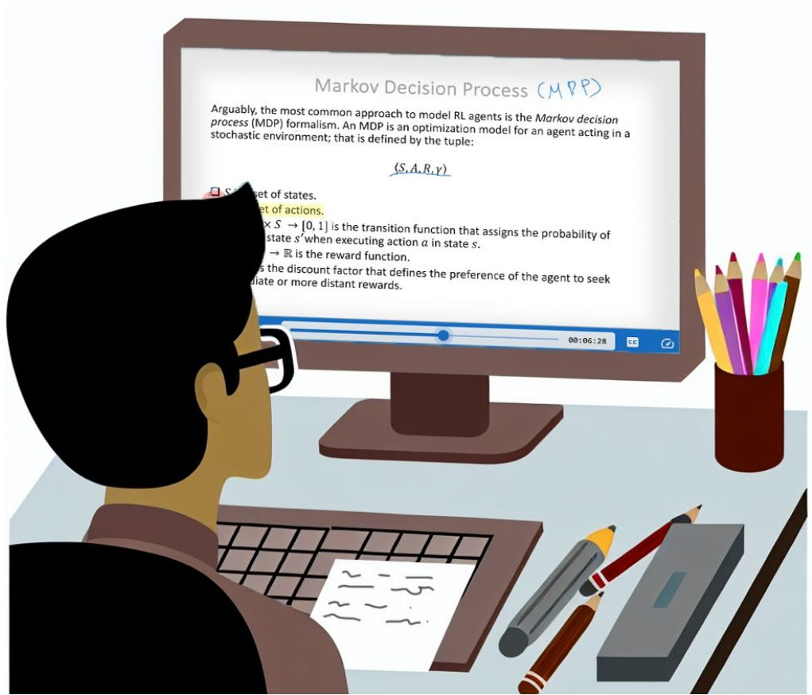

## Formative study

Our formative study reveals many existing access barriers. We conducted a web survey with 53 participants from various backgrounds (age, education, disability status, and more). Even though video-based learning is widely used, many access barriers persist.

How often participants use each form of learning (number of participants per frequency rating, 1 low to 5 high)

| Learning form | 1 | 2 | 3 | 4 | 5 | Total |
| --- | --- | --- | --- | --- | --- | --- |
| Online learning | 0 | 5 | 7 | 11 | 30 | 53 |
| Video learning | 0 | 2 | 15 | 16 | 18 | 51 |

Key findings. Videos are still hard to **follow**, **see**, and **navigate**.

## What is SmartLearn?

An accessible video-based e-learning system that uses multiple approaches to support learners with diverse abilities. It uses temporal and visual accessibility solutions, each answering one key finding:

- Smart ReplayHelps learners **follow**.
- Visual HighlightsHelps learners **see**.
- LLM ChaptersHelps learners **navigate**.

## SmartLearn system

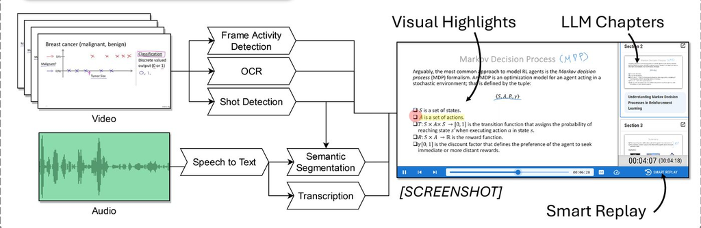

How the pipeline works:

1. **Video:** frame activity detection, OCR, and shot detection.
2. **Audio:** speech to text, then semantic segmentation (combined with shot detection) and transcription.
3. **Player:** Visual Highlights mark the active part of the slide, LLM Chapters list summarized sections, and Smart Replay sits in the playback controls.

## User study

14 participants (P1 to P14) used both SmartLearn and a baseline player, one per task.

### H1: SmartLearn is more engaging

More user interactions with the videos.

Total interactions per participant, task 2

| Participant | Condition | Total interactions |
| --- | --- | --- |
| P01 | Baseline | 7 |
| P04 | Baseline | 10 |
| P07 | Baseline | 1 |
| P09 | Baseline | 10 |
| P11 | Baseline | 7 |
| P13 | Baseline | 11 |
| P14 | Baseline | 10 |
| P02 | SmartLearn | 20 |
| P03 | SmartLearn | 28 |
| P05 | SmartLearn | 58 |
| P06 | SmartLearn | 11 |
| P08 | SmartLearn | 13 |
| P10 | SmartLearn | 36 |
| P12 | SmartLearn | 22 |

Total interactions per participant, task 1

| Participant | Condition | Total interactions |
| --- | --- | --- |
| P02 | Baseline | 9 |
| P03 | Baseline | 16 |
| P05 | Baseline | 47 |
| P06 | Baseline | 4 |
| P08 | Baseline | 12 |
| P10 | Baseline | 10 |
| P12 | Baseline | 13 |
| P01 | SmartLearn | 8 |
| P04 | SmartLearn | 6 |
| P07 | SmartLearn | 18 |
| P09 | SmartLearn | 9 |
| P11 | SmartLearn | 6 |
| P13 | SmartLearn | 16 |
| P14 | SmartLearn | 5 |

### H2: SmartLearn improves learning

Post-task quiz scores per participant

| Participant | Baseline | SmartLearn | Change |
| --- | --- | --- | --- |
| P1 | 4 | 2 | Lowered |
| P2 | 4 | 3 | Lowered |
| P3 | 5 | 2 | Lowered |
| P4 | 2 | 2 | Same |
| P5 | 4 | 4 | Same |
| P6 | 2 | 3 | Improved |
| P7 | 4 | 5 | Improved |
| P8 | 4 | 3 | Lowered |
| P9 | 2 | 4 | Improved |
| P10 | 3 | 5 | Improved |
| P11 | 3 | 4 | Improved |
| P12 | 4 | 2 | Lowered |
| P13 | 3 | 5 | Improved |
| P14 | 4 | 4 | Same |

Comparing post-task quiz results: **6 improved** their score, **3 maintained** it, and **5 lowered** it.

### H3: SmartLearn enhances user experience

Positive feedback in user evaluation.

SmartLearn: number of participants giving each score (1 low to 5 high, 14 participants)

| Measure | 1 | 2 | 3 | 4 | 5 |
| --- | --- | --- | --- | --- | --- |
| Mental demand (lower is better) | 3 | 2 | 6 | 3 | 0 |
| Ease of use | 0 | 0 | 0 | 6 | 8 |
| Usefulness | 0 | 0 | 2 | 6 | 6 |

Baseline: number of participants giving each score (1 low to 5 high, 14 participants)

| Measure | 1 | 2 | 3 | 4 | 5 |
| --- | --- | --- | --- | --- | --- |
| Mental demand (lower is better) | 0 | 1 | 7 | 4 | 2 |
| Ease of use | 0 | 1 | 5 | 4 | 4 |
| Usefulness | 0 | 2 | 6 | 5 | 1 |

## Lessons learned

- Chapter generation trade-offMore chapters give control, but fewer give a simpler experience. This calls for a balance between **detail** and **simplicity**.
- Replay button underutilizationIts distinction from chapters was confusing, its function was not unique enough, and it lacked transparency about the outcome.
- Speed change strategiesWords-per-second (WPS) speed changes led to unnatural speech and a confusing pace. But they also, unintentionally, increased attention.

## Design guidelines

- The design should be **responsive** to both user actions and content.
- The user experience should be **customizable** on all dimensions.
- The design should be **transparent** and communicate information about the system and content.